# Laboratorium 5

Rozwiązanie zadania 2

Author

Dariusz Majerek

Published

March 26, 2025

# Przygotowanie danych

```r
library(tidymodels)
library(palmerpenguins)

glimpse(penguins)
```

```
Rows: 344
Columns: 8
$ species           <fct> Adelie, Adelie, Adelie, Adelie, Adelie, Adelie, Adel…
$ island            <fct> Torgersen, Torgersen, Torgersen, Torgersen, Torgerse…
$ bill_length_mm    <dbl> 39.1, 39.5, 40.3, NA, 36.7, 39.3, 38.9, 39.2, 34.1, …
$ bill_depth_mm     <dbl> 18.7, 17.4, 18.0, NA, 19.3, 20.6, 17.8, 19.6, 18.1, …
$ flipper_length_mm <int> 181, 186, 195, NA, 193, 190, 181, 195, 193, 190, 186…
$ body_mass_g       <int> 3750, 3800, 3250, NA, 3450, 3650, 3625, 4675, 3475, …
$ sex               <fct> male, female, female, NA, female, male, female, male…
$ year              <int> 2007, 2007, 2007, 2007, 2007, 2007, 2007, 2007, 2007…
```

Dokonajmy podziału na zbiór uczący i testowy

```r
set.seed(44)
split <- initial_split(penguins, prop = 0.7, strata = species)
train <- training(split)
test <- testing(split)
```

# Budowa modeli

```r
rf <- rand_forest() %>%
  set_mode("classification") %>%
  set_engine("ranger")

svm <- svm_rbf() %>%
  set_mode("classification") %>%
  set_engine("kernlab")
```

# Uczenie modeli na zbiorze uczącym

```r
rf_fit <- rf %>% fit(species ~ ., data = train)
rf_fit
```

```
parsnip model object

Ranger result

Call:
 ranger::ranger(x = maybe_data_frame(x), y = y, num.threads = 1,      verbose = FALSE, seed = sample.int(10^5, 1), probability = TRUE)

Type:                             Probability estimation
Number of trees:                  500
Sample size:                      230
Number of independent variables:  7
Mtry:                             2
Target node size:                 10
Variable importance mode:         none
Splitrule:                        gini
OOB prediction error (Brier s.):  0.02171245
```

```r
svm_fit <- svm %>% fit(species ~ ., data = train)
svm_fit
```

```
parsnip model object

Support Vector Machine object of class "ksvm"

SV type: C-svc  (classification)
 parameter : cost C = 1

Gaussian Radial Basis kernel function.
 Hyperparameter : sigma =  0.222109163358661

Number of Support Vectors : 61

Objective Function Value : -13.9991 -4.7517 -4.0369
Training error : 0
Probability model included.
```

# Ocena dopasowania modeli

Zaczniemy od macierzy pomyłek dla modelu lasu losowego.

```r
pred_rf <- augment(rf_fit, test) |>
  select(species, .pred_class:.pred_Gentoo)

pred_rf
```

```
# A tibble: 105 × 5
   species .pred_class .pred_Adelie .pred_Chinstrap .pred_Gentoo
   <fct>   <fct>              <dbl>           <dbl>        <dbl>
 1 Adelie  Adelie             0.859         0.0896       0.0518
 2 Adelie  Adelie             0.964         0.0356       0
 3 Adelie  Adelie             0.893         0.0990       0.00831
 4 Adelie  Adelie             0.784         0.194        0.0224
 5 Adelie  Adelie             0.997         0.00264      0
 6 Adelie  Adelie             0.967         0.0304       0.00262
 7 Adelie  Adelie             0.993         0.00404      0.00329
 8 Adelie  Adelie             0.963         0.0343       0.00262
 9 Adelie  Adelie             0.971         0.0266       0.00262
10 Adelie  Adelie             0.988         0.00900      0.00262
# ℹ 95 more rows
```

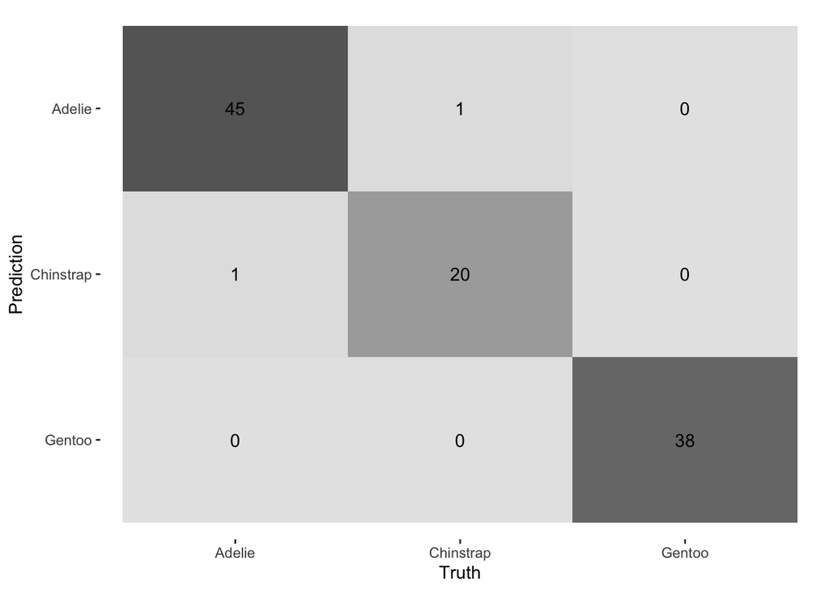

```r
cm <- pred_rf %>%
  conf_mat(species, .pred_class)

cm %>%
  autoplot(type = 'heatmap')
```

Teraz zrobimy to samo dla modelu SVM. Tym razem trzeba zaznaczyć, że ponieważ model SVM nie radzi sobie z obsługą braków danych i daje predykcje jedynie dla pełnych obserwacji, to musimy usunąć braki danych z ramki testowej.

```r
pred_svm <- augment(svm_fit, drop_na(test)) |>
  select(species, .pred_class:.pred_Gentoo)

pred_svm
```

```
# A tibble: 103 × 5
   species .pred_class .pred_Adelie .pred_Chinstrap .pred_Gentoo
   <fct>   <fct>              <dbl>           <dbl>        <dbl>
 1 Adelie  Adelie             0.989         0.00409      0.00717
 2 Adelie  Adelie             0.966         0.0113       0.0227
 3 Adelie  Adelie             0.988         0.00602      0.00549
 4 Adelie  Adelie             0.986         0.00394      0.00965
 5 Adelie  Adelie             0.984         0.00809      0.00747
 6 Adelie  Adelie             0.988         0.00564      0.00586
 7 Adelie  Adelie             0.985         0.00764      0.00746
 8 Adelie  Adelie             0.922         0.0681       0.00964
 9 Adelie  Adelie             0.964         0.0233       0.0124
10 Adelie  Adelie             0.983         0.0133       0.00343
# ℹ 93 more rows
```

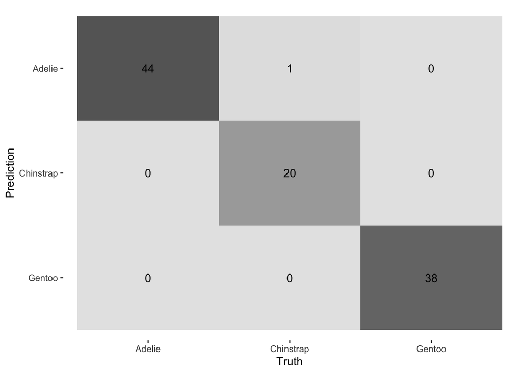

```r
cm <- pred_svm %>%
  conf_mat(species, .pred_class)

cm %>%
  autoplot(type = 'heatmap')
```

Teraz porównamy modele w kontekście wybranych metryk.

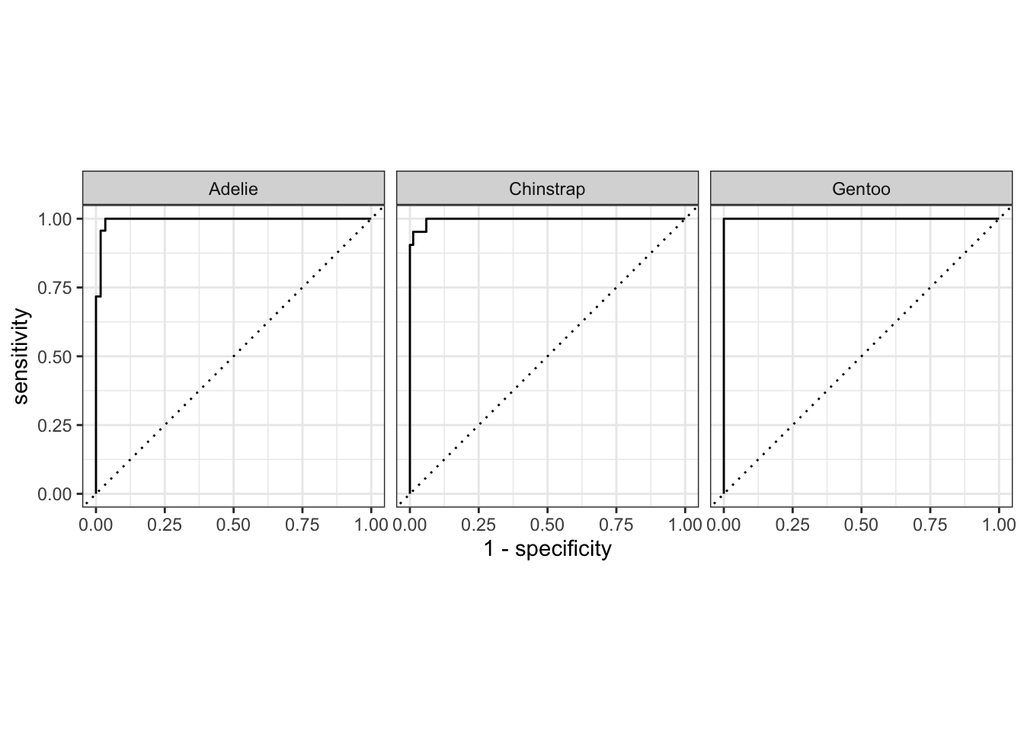

```r
acc_rf <- pred_rf %>%
  accuracy(truth = species, estimate = .pred_class)

acc_svm <- pred_svm %>%
  accuracy(truth = species, estimate = .pred_class)

f1_rf <- pred_rf %>%
  f_meas(truth = species, estimate = .pred_class, estimator = "micro")

f1_svm <- pred_svm %>%
  f_meas(truth = species, estimate = .pred_class, estimator = "micro")

pred_rf %>%
  roc_curve(truth = species, .pred_Adelie:.pred_Gentoo, estimator = "macro_weighted") %>%
  autoplot()
```

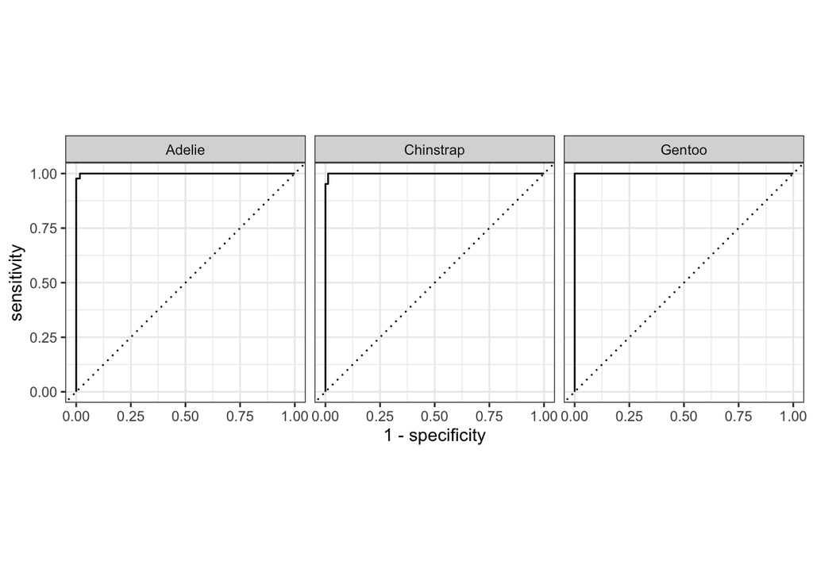

```r
pred_svm %>%
  roc_curve(truth = species, .pred_Adelie:.pred_Gentoo, estimator = "macro_weighted") %>%
  autoplot()
```

```r
auc_rf <- pred_rf %>%
  roc_auc(truth = species, .pred_Adelie:.pred_Gentoo, estimator = "macro_weighted")

auc_svm <- pred_svm %>%
  roc_auc(truth = species, .pred_Adelie:.pred_Gentoo, estimator = "macro_weighted")
```

Zbierzemy wszystkie metryki w jedną ramkę danych.

```r
bind_rows(acc_rf, f1_rf, auc_rf, acc_svm, f1_svm, auc_svm) |>
  mutate(model = rep(c("Las losowy", "SVM"), each = 3)) %>%
  arrange(.metric)
```

```
# A tibble: 6 × 4
  .metric  .estimator     .estimate model
  <chr>    <chr>              <dbl> <chr>
1 accuracy multiclass         0.981 Las losowy
2 accuracy multiclass         0.990 SVM
3 f_meas   micro              0.981 Las losowy
4 f_meas   micro              0.990 SVM
5 roc_auc  macro_weighted     0.997 Las losowy
6 roc_auc  macro_weighted     1.00  SVM
```

# Wnioski

Na podstawie przedstawionych wyników w kontekście drugiego zadania (klasyfikacja wieloklasowa) można wyciągnąć następujące wnioski:

- Dokładność (accuracy) obu modeli jest bardzo wysoka, z lekką przewagą modelu SVM (0,990 vs 0,981), co sugeruje, że SVM nieco lepiej klasyfikuje ogólnie wszystkie klasy.
- Miara F1 (f_meas) liczona jako mikro-średnia jest zgodna z wynikami dokładności – również wskazuje na niewielką przewagę modelu SVM (0,990) nad lasem losowym (0,981). Oznacza to, że model SVM skuteczniej równoważy precyzję i czułość w klasyfikacji wieloklasowej.
- AUC ROC (roc_auc) liczona jako średnia ważona dla wszystkich klas jest praktycznie idealna w obu modelach, z minimalną przewagą SVM (1,00 vs 0,997), co oznacza doskonałą zdolność modelu SVM do rozróżniania klas.

Podsumowując, oba modele prezentują bardzo wysoką jakość klasyfikacji, jednak model SVM wykazuje minimalnie lepszą wydajność we wszystkich badanych metrykach. W praktyce można wybrać SVM jako preferowany model, ale warto mieć na uwadze, że różnica jakości jest marginalna, a ostateczny wybór może zależeć również od innych czynników, takich jak szybkość działania, łatwość interpretacji czy koszt obliczeniowy.